# FigureYa231scScore

**Author(s)**: Yi Xiong  
**Date**: `r Sys.Date()`

# Academic Citation

If you use this code in your work or research, we kindly request that you cite our publication:

Xiaofan Lu, et al. (2025). FigureYa: A Standardized Visualization Framework for Enhancing Biomedical Data Interpretation and Research Efficiency. iMetaMed. https://doi.org/10.1002/imm3.70005

# 需求描述

tsne降维，标记GO功能

# Requirement Description

tsne dimensionality reduction, marking GO function

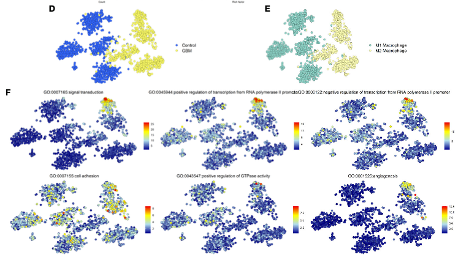

出自https://www.frontiersin.org/articles/10.3389/fimmu.2020.606164/full fromhttps://www.frontiersin.org/articles/10.3389/fimmu.2020.606164/full

FIGURE 2 | Functional enrichment analysis. (D) The distribution of GBM and Control cells in GSE135437. (E) The distribution of status of macrophages in GSE135437. (F) The distribution of top-six biological processes in GSE135437.

Almost all **M2 macrophages were in the GBM cells**, while **M1 macrophages were in the control cells** (Figures 2D, E). Furthermore we explored the **relationship between the biological process and cell types** and found that the signal transduction and angiogenesis enriched in a subgroup of M2 macrophages, however the cell adhesion widely distributed in both control and GBM cells (Figure 2F).

# 应用场景

单细胞数据，从matrix到分组，用Single-Cell Signature Explorer 软件计算pathway的表达量，相比于FigureYa160scGSVA所用的GSVA运行速度更快。

# Application Scenarios

Single-cell data, from matrix to grouping, was calculated using Single-Cell Signature Explorer software, which was faster than the GSVA used in the FigureYa160sc GSVA.

> 怎样从t-SNE图中解读出有意义的信息？

需要从各个角度对比展示，从而找到能讲故事的角度：

- 用颜色标注各种细胞类群、突出显示其中某一/几种细胞类型、显示分组/分类信息等等。总之把你想要展示的细胞信息放在metadata里，就可以了。方法见下文“ 根据metadata里的信息分组”。
- 展示某一/几个基因（例如marker基因）的表达量跟细胞类型之间的关系，可参考FigureYa27t-SNE。
- 展示pathway的表达量跟细胞类型直接的关系。本文档“用渐变色展示pathway的表达量”部分将用Single-Cell Signature Explorer计算 score。另外，pathway的表达量还可以并用小提琴图的方式展示，并计算pathway在组间的差异显著性，可参考FigureYa160scGSVA。

> How can meaningful information be deduced from t-SNE plots?

You need to compare and contrast the presentation from various angles to find the angle from which the story can be told:

- Color-code various cell populations, highlight one/several cell types, display grouping/taxonomic information, and more. In short, put the cell information you want to display in metadata, and you’re good to go. See below for the method, “Grouping by information in metadata”.
- To show the relationship between the expression of one or several genes (e.g., marker gene) and cell type, refer to FigureYa27t-SNE.
- Demonstrate a direct relationship between pathway expression and cell type. In the section of this document, “Showing the Expression of a Pathway with Gradient Colors”, the score will be calculated using the Single-Cell Signature Explorer. In addition, the expression of pathway can also be displayed in the form of violin diagram, and the significance of the difference of pathway between groups can be calculated, which can be referred to FigureYa160scGSVA.

# Environment settings

```r
source("install_dependencies.R")
```

```
## Starting R package installation...
## ===========================================
##
## Installing CRAN packages...
## Package already installed: RColorBrewer
## Package already installed: Seurat
## Package already installed: tidyverse
##
## Installing Bioconductor packages...
## Package already installed: GO.db
## Package already installed: biomaRt
##
## ===========================================
## Package installation completed!
## You can now run your R scripts in this directory.
```

```r
library(tidyverse)
library(Seurat)
library(GO.db)
library(biomaRt)
library(RColorBrewer)

Sys.setenv(LANGUAGE = "en") #显示英文报错信息  # error messages are displayed in English
options(stringsAsFactors = FALSE) #禁止chr转成factor # chr is not allowed to be converted to factor
```

# 标准的seurat流程

GSE135437，从https://github.com/rsankowski/sankowski-et-al-microglia下载数据并解压到当前文件夹

# Standard Seurat process

GSE135437, download the data from the https://github.com/rsankowski/sankowski-et-al-microglia and extract it to the current folder

```r
#读取作者处理好的数据
# Read the data processed by the author
(load("data/unnormalized_counts_ctrl_gbm.RData")) # 表达矩阵 # Expression matrix
```

```
## [1] "counts_unnorm"
```

```r
(load("data/metadata-ctrl-gbm.RData")) # metadata
```

```
## [1] "df"
```

运行标准的seurat流程 Run the standard seurat process

```r
metadata = df; rownames(metadata) = df$cell_ID

# 创建Seurat对象
# Create a Seurat object
SeuratObj <- CreateSeuratObject(counts = counts_unnorm,
                                project = "ctrl-gbm",
                                min.cells = 3,
                                min.features = 200,
                                meta.data = metadata)
```

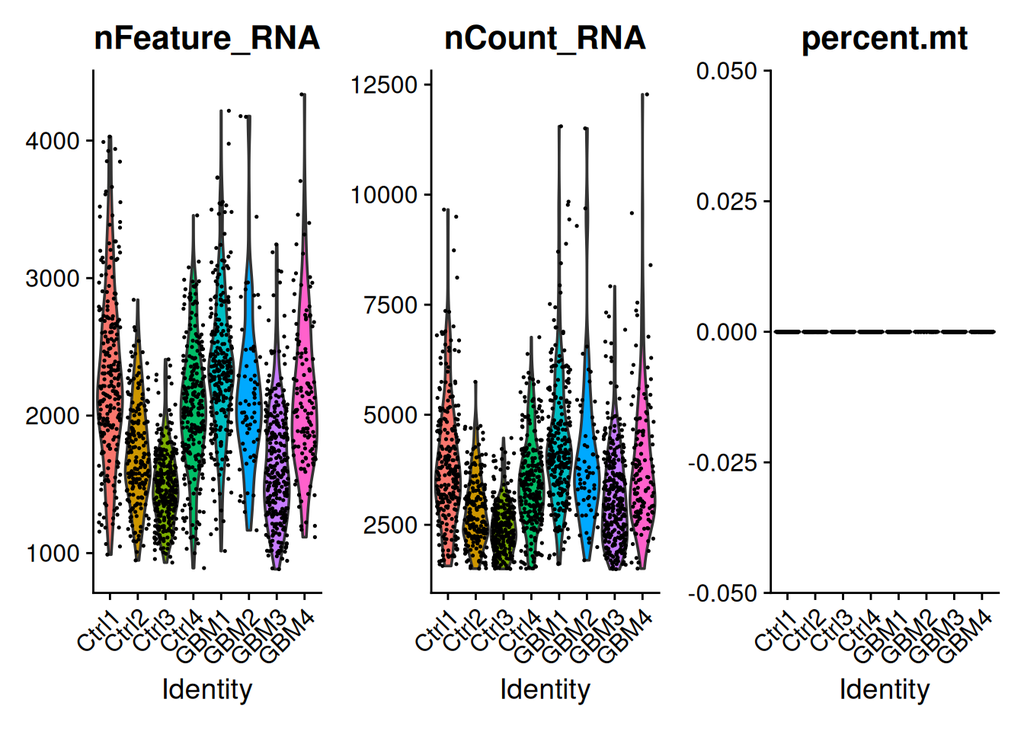

```r
# 提取线粒体基因
# Extract mitochondrial genes
SeuratObj[["percent.mt"]] <- PercentageFeatureSet(SeuratObj, pattern = "^MT-")

# 这个地方表达矩阵内无线粒体基因，所以不进行过滤
# This place expresses the un-partondrial genes within the matrix, so it is not filtered
VlnPlot(SeuratObj, features = c("nFeature_RNA", "nCount_RNA", "percent.mt"), ncol = 3)
```

```r
# 进行标准化，归一化
# Standardization, normalization
SeuratObj = SeuratObj %>%
  NormalizeData() %>%
  FindVariableFeatures() %>%
  ScaleData()
```

```
## Normalizing layer: counts
```

```
## Finding variable features for layer counts
```

```r
# 运行PCA
# Run PCA
SeuratObj = RunPCA(SeuratObj, features = VariableFeatures(object = SeuratObj))
```

```
## PC_ 1
## Positive:  XIST, HLA-DRB5, ACY3, RP11-326N17.2, LINC00996, CTC-340A15.2, ITM2C, DUXAP8, GABPB1-AS1, USP53
##     RP11-57H12.3, LYVE1, ATXN3, RP11-230F18.5, OPHN1, P2RY12, LINC01268, LRRC4, MRC1, RP11-727A23.10
##     TPTEP1, AC092415.1, OLMALINC, ABCG2, GNLY, CH507-154B10.1, ADAMTS4, CKB, CTC-436K13.3, GRID2
## Negative:  APOE, RGS1, SRGN, B2M, SGK1, CD163, CD83, IFITM3, CXCR4, FTL
##     APOC1, C5AR1, NR4A3, CEBPD, PLAUR, GPX1, ZFP36, MAFB, ACSL1, SPP1
##     IFI44L, MSR1, TGFBI, HLA-A, IFI6, PADI2, SAT1, HBEGF, NR4A2, RPS26
## PC_ 2
## Positive:  FKBP5, SPP1, SERPINE1, GLDN, SERPINF1, FTL, CPM, VSIG4, CACNA1A, PLAC8
##     HLA-A, ZBTB16, WNT5A, LPL, APOE, APOC1, PIAS2, PARP9, PTCRA, TXNIP
##     PLTP, FCGR3A, S100A9, CTSD, MS4A6A, CHI3L1, LINC01513, DDIT4, IFI44L, IFI27
## Negative:  NR4A2, CD83, NR4A3, CH25H, CTC-340A15.2, C5AR1, VEGFA, CCDC168, AC092415.1, ERVH-1
##     RP11-727A23.10, FOSL2, RP11-467L19.14, CREM, HBEGF, ZNF331, SAT1, MCL1, EGR3, GADD45B
##     OPHN1, CTC-436K13.3, MIR100HG, MUC3A, NAMPT, RP11-57H12.3, AC007743.1, GNA13, RP11-65G9.1, SRGN
## PC_ 3
## Positive:  EGR1, FOS, CH17-373J23.1, CCL3L3, EGR2, DUSP1, CH25H, FOSB, BTG2, JUNB
##     EGR3, CCL4, CDKN1A, CCL4L2, CTD-3014M21.1, IER2, CD83, KLF6, KLF2, JUN
##     DDX3Y, OLR1, PPP1R15A, KLF4, U1, CCL2, ZFP36, RTTN, TNF, IER3
## Negative:  MTRNR2L12, CD163, VSIG4, FKBP5, CH507-154B10.1, SIGLEC1, USP53, IFITM3, XIST, WNT5A
##     NPC2, FCGBP, CRYAB, TXNIP, PLP1, HSPA1A, MOBP, IQGAP1, APLP1, IFI6
##     IFI27, CPM, GNLY, LGALS3BP, CTC-340A15.2, FCGR3A, DSE, GPR65, MS4A4A, APOC1
## PC_ 4
## Positive:  IFI44L, JUN, ERVH-1, AC092415.1, RP11-727A23.10, AC007743.1, MUC3A, SAMD9L, TPTEP1, OLMALINC
##     RP11-35J1.2, RP11-326N17.2, CH17-373J23.1, MUC6, IFIT3, RP11-57H12.3, MX1, CTC-340A15.2, FOS, OPHN1
##     CMYA5, CTD-3014M21.1, AC003973.3, FOSB, IFI27, ATXN3, FTL, JUNB, IFI44, PCLO
## Negative:  APLP1, PLP1, CRYAB, MAG, MOBP, CLDN11, MAL, TPPP3, MAP1A, MRC1
##     PLEKHB1, APOD, CCL2, LYVE1, GPM6B, PLTP, MAP1B, LINC01513, CLDND1, CAMK2N1
##     IVNS1ABP, DBNDD2, IL1B, CH25H, CCL4L2, RNASE1, STAB1, PCDH12, STMN1, CDC42EP1
## PC_ 5
## Positive:  ADAM10, PIWIL1, LINC01513, NEDD9, ETS2, MRC1, VSIG4, HLA-DRB5, CD163, FKBP5
##     XIST, CLEC5A, VEGFA, PDE6A, RP11-230F18.5, DDIT4, C5AR1, CEBPD, ZBTB16, LYVE1
##     HIF1A, SESN1, CREM, PDGFB, CTD-2353F22.2, TFRC, HERPUD1, CACNA1A, ARRDC3, NR4A3
## Negative:  APLP1, CRYAB, MAG, PLP1, MOBP, CLDN11, MAL, TPPP3, DBNDD2, MAP1A
##     PLEKHB1, IFI44L, APOD, MX1, IFIT3, GPM6B, IFI27, MAP1B, IFI6, MX2
##     RSAD2, LY6E, DUSP1, ACTB, IFIT1, IFIT2, CHI3L1, RPS26, CLDND1, PARP9
```

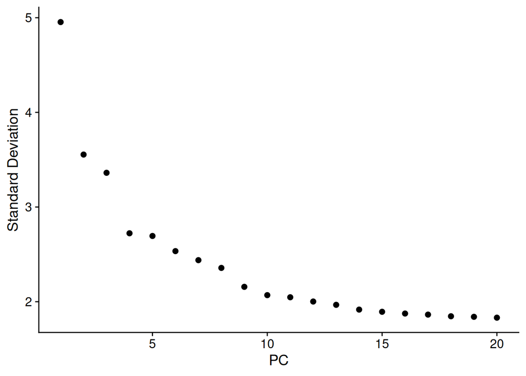

```r
ElbowPlot(SeuratObj)
```

```r
# 选取前10个PC进行降维
# Select the first 10 PCs for dimensionality reduction
SeuratObj = RunTSNE(SeuratObj,dims = 1:10)
```

# 用不同颜色展示分组

# Show the grouping with different colors

## Group according to Patient_ID

查看来自不同人的细胞分布情况 See the distribution of cells from different people

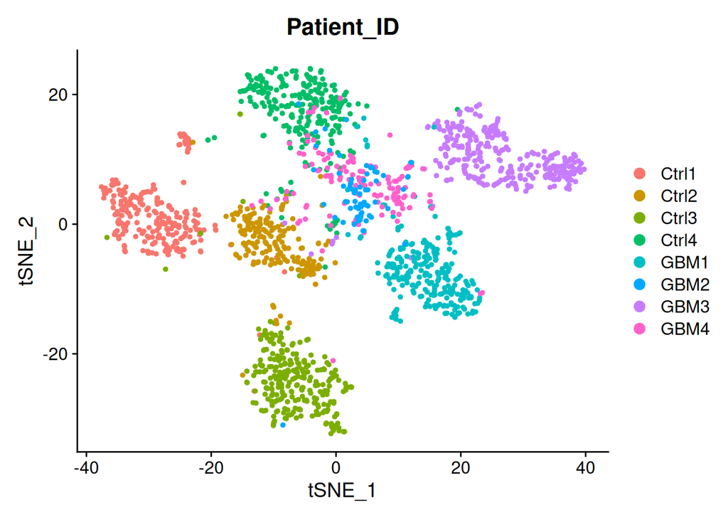

```r
DimPlot(SeuratObj,
        reduction = "tsne",
        group.by = "Patient_ID")
```

可以看出Ctrl在左，GBM在右。下面用两种颜色标注，更直观。 You can see that Ctrl is on the left and GBM is on the right. The following is marked with two colors, which is more intuitive.

## 根据Diagnosis列分组 - 画图2D

## Grouping by Diagnosis Column - Paint 2D

GBM和Ctrl两组 GBM and Ctrl

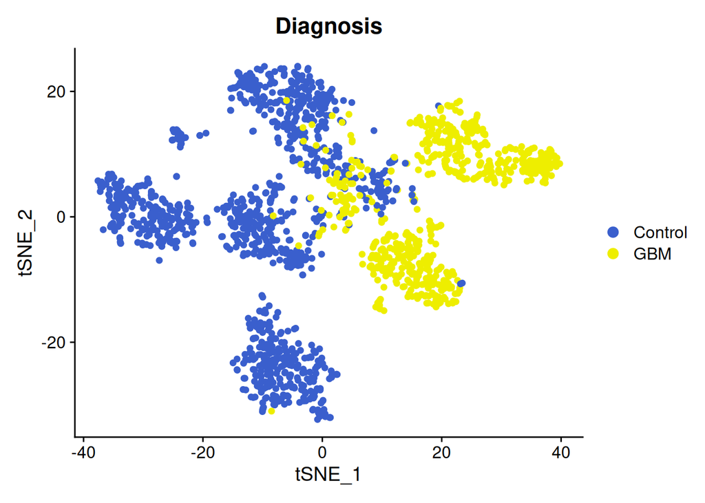

```r
DimPlot(SeuratObj,
        reduction = "tsne",
        group.by = "Diagnosis", # metadata的Diagnosis列
        cols = c("royalblue3", "yellow2"),
        pt.size = 1.5)
```

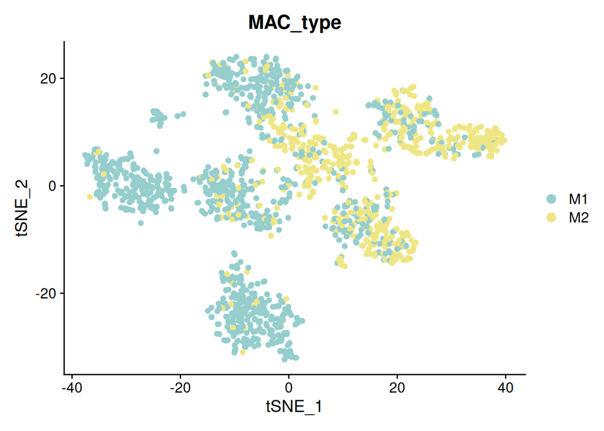

```r
# 根据作者文章的定义对巨噬细胞进行分类
# Classify macrophages according to the definition in the author's article
Putative_M2_cells <- WhichCells(SeuratObj, expression = CD163 >= 1 | FPR3 >= 1 | SIGLEC1 >= 1)

metadata$MAC_type = ifelse(metadata$cell_ID %in% Putative_M2_cells,"M2","M1")
SeuratObj$MAC_type = metadata$MAC_type

# 复现图2E
# Reproduce Figure 2E
DimPlot(SeuratObj,
        reduction = "tsne",
        group.by = "MAC_type",
        cols = c("paleturquoise3", "khaki2"),
        pt.size = 1.5)
```

```r
# 保存数据，后面接着用
# Save the data and use it later
#saveRDS(SeuratObj,"./SeuratObj.rds")
```

# 用渐变色展示pathway的表达量 - Single-Cell Signature Explorer score

# Single-Cell Signature Explorer score is displayed with gradient color

```r
# 读取前面保存的数据
# Read the previously saved data
SeuratObj <- readRDS("./SeuratObj.rds")

# 准备好表达矩阵，作为Single Cell Scorer软件的输入
# Prepare the expression matrix as input to the Single Cell Scorer software
write.table(t(as.matrix(SeuratObj@assays$RNA$data)), "SeuratObj.tsv", sep="\t", row.names = TRUE, col.names=NA)
```

## Prepare the gene set

```r
ensembl <- useMart("ensembl",dataset="hsapiens_gene_ensembl") #uses human ensembl annotations

# 要展示的GO term
# GO term to showcase
go_id <- c("GO:0007165",#signal transduction
         "GO:0045944",#positive regulation of transcription from RNA polymerase 2 promoter
         "GO:0000122",#negative regulation of transcription from RNA polymerase 2 promoter
         "GO:0007155",#cell adhesion
         "GO:0043547",# positive regulation of GTPase activity
         "GO:0001525")#angiogenesis

# 提取每个GO term里的基因
# Extract the genes in each GO term
data <- list()
for (i in go_id) {
  gene.data <- getBM(attributes=c('hgnc_symbol', 'go_id'),
                     filters = 'go', values = i, mart = ensembl)
  gene <- unique(gene.data$hgnc_symbol)
  data[[i]] <- gene
}

# saveRDS(data,"GO_genelist.rds")
```

准备好基因集，保存到`geneset`文件夹下，作为Single Cell Scorer软件的输入 Prepare the gene set and save it to the ‘geneset’ folder as input to the Single Cell Scorer software

```r
for (i in c(1:length(data))) {
  # i = 1
  id = names(data)[i]
  id = gsub(":", "_", id)
  gene = data[[i]]
  gene = data.frame(gene = gene)
  write.table(gene, file=paste0("./geneset/",id,".txt"), quote=FALSE,row.names = F,col.names=F)
}
```

## 使用Single-Cell Signature Explorer进行打分

在此下载 https://sites.google.com/site/fredsoftwares/products/single-cell-signature-explorer，下载后文件夹下有操作手册。

## Use the Single-Cell Signature Explorer for scoring

In this download https://sites.google.com/site/fredsoftwares/products/single-cell-signature-explorer, there is an operation manual under the folder after downloading.

The **Single-Cell Signature Scorer** was compiled for GNU Linux and Microsoft©Windows™ 64 bits, and can be compiled for any platform using cross-compilation by Go. https://academic.oup.com/nar/article/47/21/e133/5531181

Windows系统下Single-Cell Signature Explorer的使用：

1. 将SeuratObj.tsv软件复制到SingleCellSignatureScorer/data文件夹下
2. 将geneset文件复制到到SingleCellSignatureScorer/databases/SignatureExamples文件夹下，可以替代示例文件
3. 双击SingleCellSignatureScorer_Win64_036.exe，输入0，然后回车
4. 结果在SingleCellSignatureScorer/results中

Using Single-Cell Signature Explorer on Windows:

1. Copy the SeuratObj.tsv software to the SingleCellSignatureScorer/data folder
2. Copy the geneset file to the SingleCellSignatureScorer/databases/SignatureExamples folder as an alternative to the sample file
3. Double-click on the SingleCellSignatureScorer_Win64_036.exe, enter 0, and press Enter

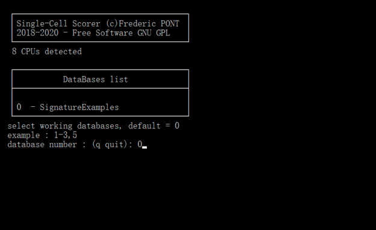

4. The results are in SingleCellSignatureScorer/results

## 读取打分结果并画图

## Read the scoring results and draw a graph

```r
# 读入Single-Cell Signature Explorer算出的score
# Read the score calculated by the Single-Cell Signature Explorer
score <- read.table("./SignatureExamples_SeuratObj.tsv",header = T,row.names = 1)

# 把Single-Cell Signature Explorer算出的score添加进去
# Add the score calculated by the Single-Cell Signature Explorer
SeuratObj = AddMetaData(SeuratObj, score, col.name = colnames(score))

#查看新的的metadata
# View the new metadata
head(SeuratObj[[]])
```

```
##          orig.ident nCount_RNA nFeature_RNA Cluster         V1         V2
## Ctrl4_11      Ctrl4   3799.431         2206       1 -3.5674499 -23.821204
## Ctrl4_12      Ctrl4   3808.288         2181       2  3.3783577 -20.348490
## Ctrl4_13      Ctrl4   4210.837         2433       3  0.6152321   1.317897
## Ctrl4_14      Ctrl4   5715.458         2777       1 -0.9053861 -20.935652
## Ctrl4_15      Ctrl4   1659.541         1148       1 -5.2841864 -18.744501
## Ctrl4_16      Ctrl4   4181.126         2482       4  1.2356736 -13.146769
##           cell_ID Patient_ID Diagnosis percent.mt MAC_type GO_0000122
## Ctrl4_11 Ctrl4_11      Ctrl4   Control          0       M1      5.697
## Ctrl4_12 Ctrl4_12      Ctrl4   Control          0       M2      5.474
## Ctrl4_13 Ctrl4_13      Ctrl4   Control          0       M1      5.493
## Ctrl4_14 Ctrl4_14      Ctrl4   Control          0       M1      5.546
## Ctrl4_15 Ctrl4_15      Ctrl4   Control          0       M1      5.670
## Ctrl4_16 Ctrl4_16      Ctrl4   Control          0       M2      5.857
##          GO_0001525 GO_0007155 GO_0007165 GO_0043547 GO_0045944
## Ctrl4_11      1.067      2.641      8.235      2.670      6.422
## Ctrl4_12      1.075      2.851      8.557      2.062      6.271
## Ctrl4_13      1.578      2.834      8.186      2.306      7.109
## Ctrl4_14      1.389      3.046      8.713      2.126      6.874
## Ctrl4_15      1.540      3.072      8.838      2.789      7.781
## Ctrl4_16      1.078      3.042      7.781      2.281      6.124
```

复现图2F Reproduce Figure 2F

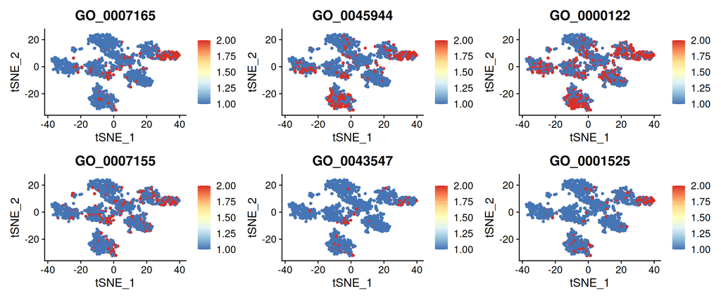

```r
FeaturePlot(SeuratObj,
            features = c("GO_0007165","GO_0045944","GO_0000122","GO_0007155","GO_0043547","GO_0001525"),
            reduction = "tsne",
            ncol = 3, # 画三列
            cols = colorRampPalette(rev(brewer.pal(n = 7, name = "RdYlBu")))(100)) # 或rev(rainbow(5))
```

```r
ggsave("scScore.pdf", width = 12, height = 5)
```

# 后期处理

输出的pdf文件都是矢量图，可以用矢量图工具打开，编辑文字和图形。例如像例文那样删掉坐标轴等。

# Post-processing

The output PDF files are all vector graphics, which can be opened with vector tools to edit text and graphics. For example, delete the axes as in the examples.